# Predicting House Prices in New Delhi

Group Number 10 (Aditya Badonia, Harshvardhan, Oshin Singal, P Suranjana)

2020-10-20

# Introduction

Buying and selling a real estate is a very complicated issue. Apart from regulatory and legal issues, an economic issue of pricing is at its core. There is no concrete price discovery mechanism in existence and usually first person negotiations decide the price. This project is an attempt to predict price of a house based on its details such as number of bedrooms, area, etc.

## Goals and Methodologies

The aim of this project is to predict prices of house. We compare four methodologies: multilinear regression, splines, classification and regression trees and neural networks.

## Data Source

This dataset was downloaded from Kaggle (https://www.kaggle.com/neelkamal692/delhi-house-price-prediction.)). The data was scrapped from web pages of Magic Bricks, a popular platform for buying and selling real estate.

# Data Cleaning and Exploration

## Missing Values

```r
library(tidyverse)
dat <- read.csv("MagicBricks.csv", header = TRUE)
str(dat)
```

```
## 'data.frame':    1259 obs. of  11 variables:
##  $ Area       : num  800 750 950 600 650 1300 1350 650 985 1300 ...
##  $ BHK        : int  3 2 2 2 2 4 4 2 3 4 ...
##  $ Bathroom   : int  2 2 2 2 2 3 3 2 3 4 ...
##  $ Furnishing : chr  "Semi-Furnished" "Semi-Furnished" "Furnished" "Semi-Furnished" ...
##  $ Locality   : chr  "Rohini Sector 25" "J R Designers Floors, Rohini Sector 24" "Citizen Apartment, Rohini Sector 13" "Rohini Sector 24" ...
##  $ Parking    : int  1 1 1 1 1 1 1 1 1 1 ...
##  $ Price      : int  6500000 5000000 15500000 4200000 6200000 15500000 10000000 4000000 6800000 15000000 ...
##  $ Status     : chr  "Ready_to_move" "Ready_to_move" "Ready_to_move" "Ready_to_move" ...
##  $ Transaction: chr  "New_Property" "New_Property" "Resale" "Resale" ...
##  $ Type       : chr  "Builder_Floor" "Apartment" "Apartment" "Builder_Floor" ...
##  $ Per_Sqft   : int  NA 6667 6667 6667 6667 6667 6667 6154 6154 6154 ...
```

```r
# Missing values?
sum(is.na(dat))
```

```
## [1] 276
```

```r
# Let us fill all missing values with mode of that variable
dat_Mode<-function(x){
  return(names(which.max(table(x))))
}

dat[is.na(dat$Parking),]$Parking = dat_Mode(dat$Parking)
dat[is.na(dat$Bathroom),]$Bathroom = dat_Mode(dat$Bathroom)
dat[dat$Furnishing == "",]$Furnishing = dat_Mode(dat$Furnishing)
dat[dat$Type == "",]$Type = dat_Mode(dat$Type)

# saving this clean dataset for future use
write.csv(dat, file = "DelhiHousingClean.csv", row.names = F)
```

## Data Visualisation

```r
rm(list = ls())
# loading data
data = read.csv("DelhiHousingClean.csv", head = T, stringsAsFactors = T)
head(data)
```

```
##   Area BHK Bathroom     Furnishing
## 1  800   3        2 Semi-Furnished
## 2  750   2        2 Semi-Furnished
## 3  950   2        2      Furnished
## 4  600   2        2 Semi-Furnished
## 5  650   2        2 Semi-Furnished
## 6 1300   4        3 Semi-Furnished
##                                                                                                                                                                                                                                                                                                          …
## 1                                                                                                                                                                                                                                                                                                        …
## 2                                                                                                                                                                                                                                                                                                        …
## 3                                                                                                                                                                                                                                                                                                        …
## 4                                                                                                                                                                                                                                                                                                        …
## 5 Rohini Sector 24 carpet area 650 sqft status Ready to Move floor 4 out of 4 floors transaction New Property furnishing Semi-Furnished facing East overlooking Garden/Park, Main Road car parking 1 Open bathroom 2 balcony 1 ownership Freehold Newly Constructed Property Newly Constructed Property E…
## 6                                                                                                                                                                                                                                                                                                        …
##   Parking    Price        Status  Transaction          Type Per_Sqft
## 1       1  6500000 Ready_to_move New_Property Builder_Floor       NA
## 2       1  5000000 Ready_to_move New_Property     Apartment     6667
## 3       1 15500000 Ready_to_move       Resale     Apartment     6667
## 4       1  4200000 Ready_to_move       Resale Builder_Floor     6667
## 5       1  6200000 Ready_to_move New_Property Builder_Floor     6667
## 6       1 15500000 Ready_to_move New_Property Builder_Floor     6667
```

```r
str(data)
```

```
## 'data.frame':    1259 obs. of  11 variables:
##  $ Area       : num  800 750 950 600 650 1300 1350 650 985 1300 ...
##  $ BHK        : int  3 2 2 2 2 4 4 2 3 4 ...
##  $ Bathroom   : int  2 2 2 2 2 3 3 2 3 4 ...
##  $ Furnishing : Factor w/ 3 levels "Furnished","Semi-Furnished",..: 2 2 1 2 2 2 2 2 3 2 ...
##  $ Locality   : Factor w/ 365 levels "Aashirwaad Chowk, Dwarka",..: 284 140 50 282 283 282 282 90 279 280 ...
##  $ Parking    : int  1 1 1 1 1 1 1 1 1 1 ...
##  $ Price      : int  6500000 5000000 15500000 4200000 6200000 15500000 10000000 4000000 6800000 15000000 ...
##  $ Status     : Factor w/ 2 levels "Almost_ready",..: 2 2 2 2 2 2 2 2 1 2 ...
##  $ Transaction: Factor w/ 2 levels "New_Property",..: 1 1 2 2 1 1 2 1 1 1 ...
##  $ Type       : Factor w/ 2 levels "Apartment","Builder_Floor": 2 1 1 2 2 2 2 1 2 2 ...
##  $ Per_Sqft   : int  NA 6667 6667 6667 6667 6667 6667 6154 6154 6154 ...
```

Most variables are categorical in nature; only area and price are continious. Further, ‘Locality’ apparently has 365 levels. This might not be entirely accurate many addresses are repeated. For example, “Rohini Sector 24” and “Rohini Sector 24 carpet area 650 sqft status…” are in the same locality. But because of poor web scrapping, errors have popped up.

While recognising that there is need for cleaning this variable, we will skip that part for the paucity of time.

So, assuming that each entry is unique, let’s explore.

The variable `Per_Sqft` is mostly Price/Area. Therefore, we exclude it to avoid multicollinearity problems.

```r
data = dplyr::select(data, -Per_Sqft, -Locality)

area = data$Area
bhk = data$BHK
bath = data$Bathroom
furnish = data$Furnishing
park = data$Parking
price = data$Price
status = data$Status
trans = data$Transaction
type = data$Type
```

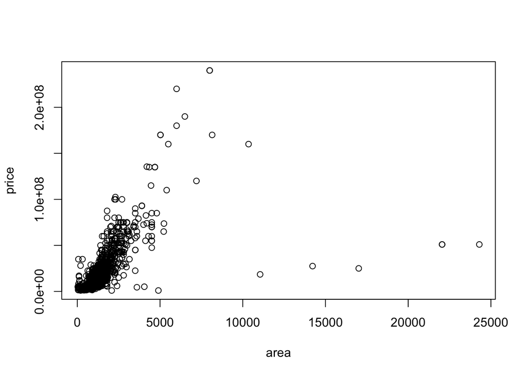

```r
# Area vs Price
plot(area, price)
```

Most are concentrated in the lower are limit and lower price limit. So, let’s reset the limits.

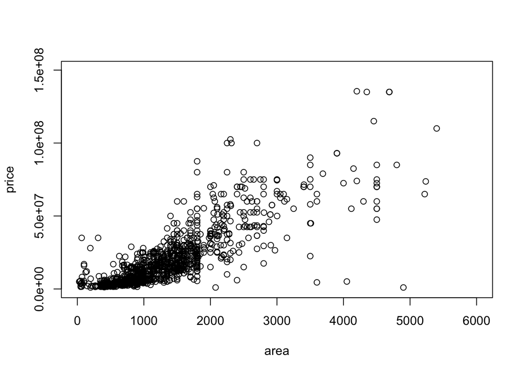

```r
plot(area, price, xlim = c(0,6000), ylim = c(0,1.5e8))
```

The general trend is that as area increases, the price increases.

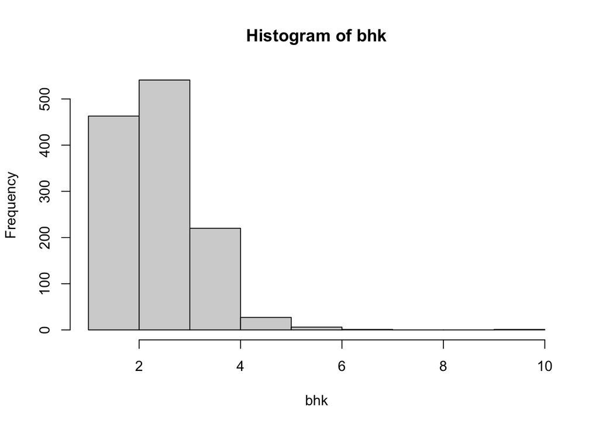

```r
# BHK
hist(bhk)
```

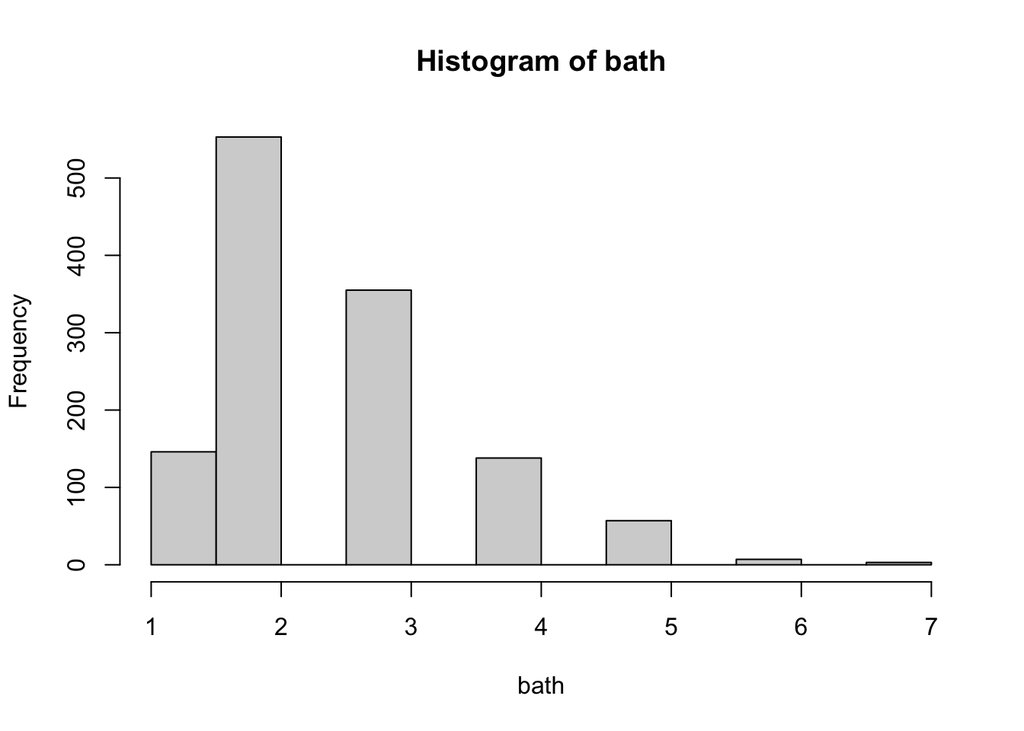

```r
# Bathroom
hist(bath)
```

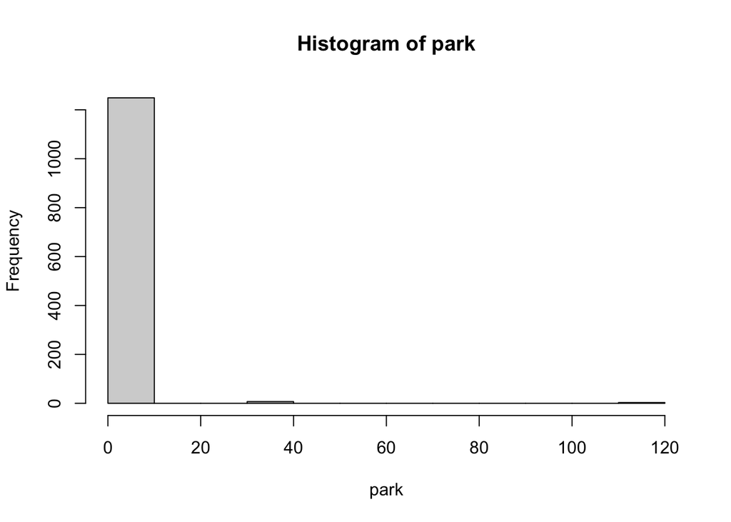

```r
# Parking
hist(park)
```

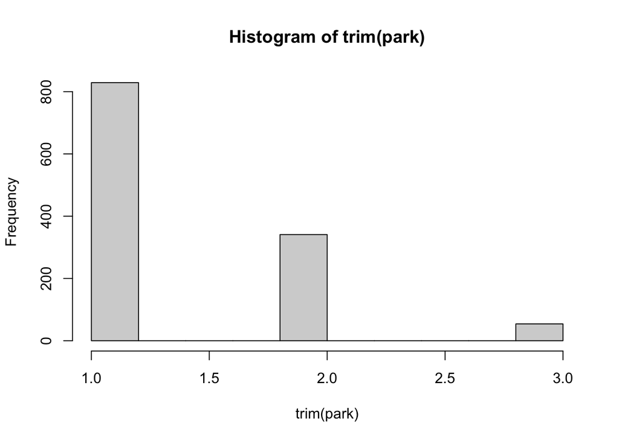

```r
# to eliminate outliers as they are skewing the histogram
trim <- function(x){
  x[(x > mean(x, na.rm = T)-1.5*IQR(x, na.rm = T)) & (x < mean(x, na.rm = T)+1.5*IQR(x, na.rm = T))]
}
hist(trim(park))
```

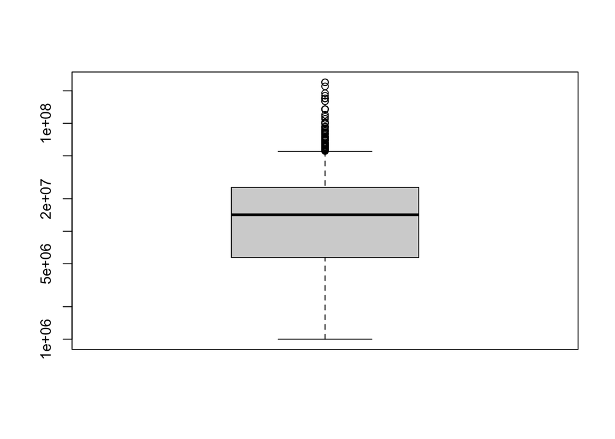

```r
# Price
boxplot(price, log = "y")
```

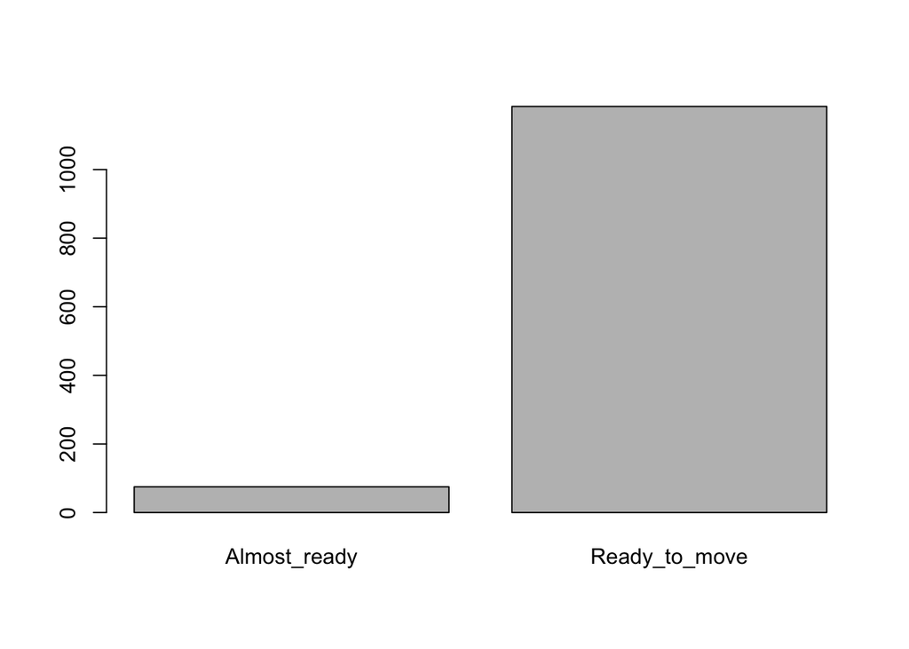

```r
# Status
barplot(table(status))
```

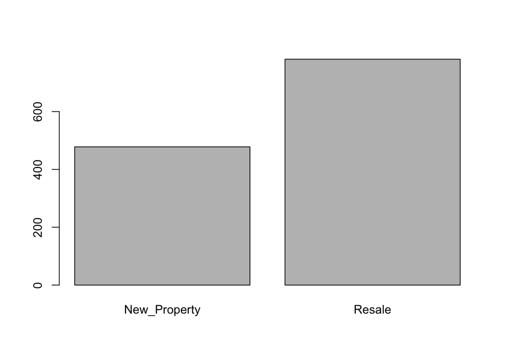

```r
# Transaction
barplot(table(trans))
```

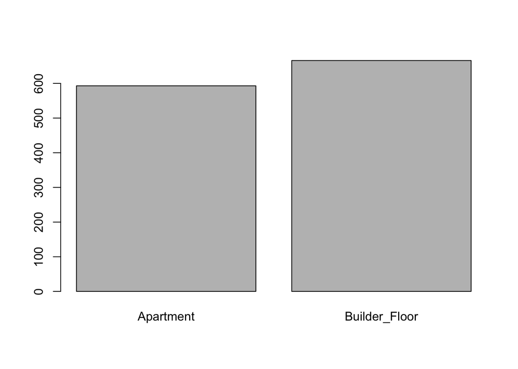

```r
# Type
barplot(table(type))
```

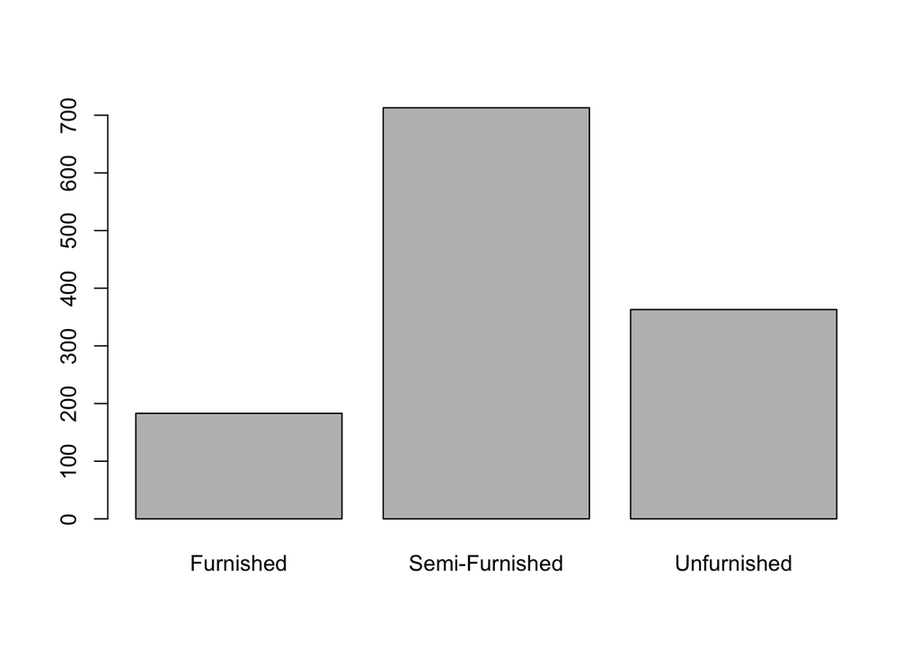

```r
# Furnishing
barplot(table(furnish))
```

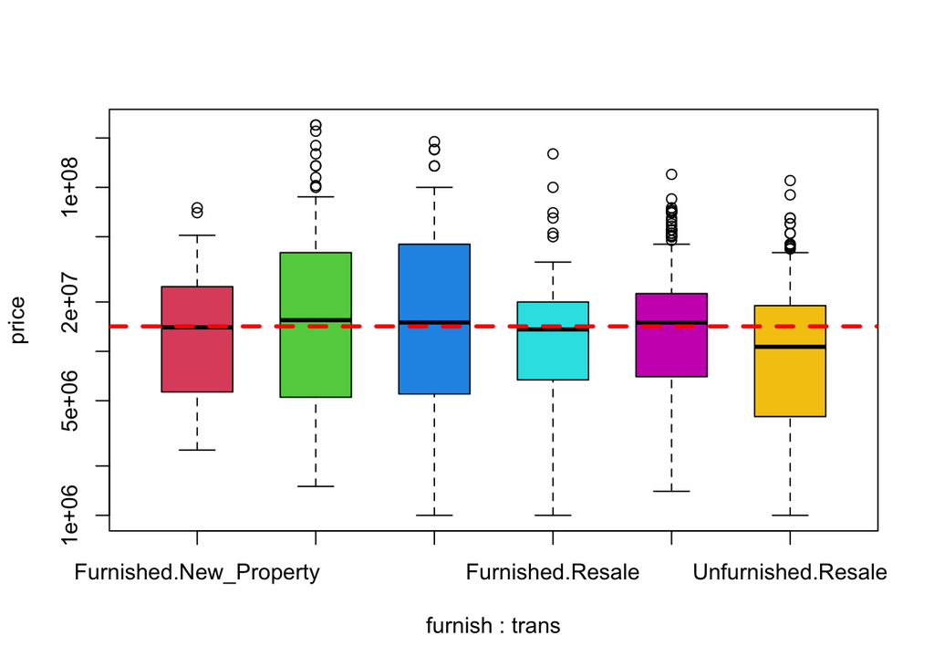

```r
# Price by Furnishing and Transaction - log scaled
# trans tell us if the house is new or being resold
boxplot(price~furnish+trans, col = 2:8, drop = T, boxwex = 0.6, log = "y", na.rm = T)
abline(h = median(price), col = "red", lwd = 3, lty = 2)
```

# Modelling House Prices

## Multilinear Regression

```r
rm(list = ls())
library(tidyverse)
library(modelr)

dat = read.csv("DelhiHousingClean.csv", head = T, stringsAsFactors = T)

#splitting into training and test data
set.seed(123)
dat.split <- modelr::resample_partition(dat, c(test = 0.3, train = 0.7))

train <- as_tibble(dat.split$train)
test <- as_tibble(dat.split$test)
```

Fitting regression model:

```r
#linear regression
dat.lm <- lm(Price ~ Area + BHK + Bathroom + Furnishing  + Parking + Status + Transaction + Type, data = train)
summary(dat.lm)
```

```
##
## Call:
## lm(formula = Price ~ Area + BHK + Bathroom + Furnishing + Parking +
##     Status + Transaction + Type, data = train)
##
## Residuals:
##       Min        1Q    Median        3Q       Max
## -95594156  -6561155  -1649156   6087050 151380326
##
## Coefficients:
##                            Estimate Std. Error t value Pr(>|t|)
## (Intercept)              -1.639e+07  3.445e+06  -4.757  2.3e-06 ***
## Area                      4.902e+03  4.322e+02  11.342  < 2e-16 ***
## BHK                      -7.256e+05  9.382e+05  -0.773   0.4395
## Bathroom                  1.456e+07  9.117e+05  15.970  < 2e-16 ***
## FurnishingSemi-Furnished -1.708e+05  1.627e+06  -0.105   0.9164
## FurnishingUnfurnished     1.849e+06  1.777e+06   1.040   0.2985
## Parking                   5.794e+04  9.017e+04   0.643   0.5207
## StatusReady_to_move      -3.599e+06  2.572e+06  -1.399   0.1621
## TransactionResale        -2.897e+06  1.241e+06  -2.334   0.0198 *
## TypeBuilder_Floor        -3.864e+05  1.155e+06  -0.335   0.7380
## ---
## Signif. codes:  0 '***' 0.001 '**' 0.01 '*' 0.05 '.' 0.1 ' ' 1
##
## Residual standard error: 16470000 on 872 degrees of freedom
## Multiple R-squared:  0.5983, Adjusted R-squared:  0.5942
## F-statistic: 144.3 on 9 and 872 DF,  p-value: < 2.2e-16
```

```r
#removing 'Type'
dat.lm2 <- lm(Price ~ Area + BHK + Bathroom + Furnishing  + Parking + Status + Transaction, data = train)
summary(dat.lm2)
```

```
##
## Call:
## lm(formula = Price ~ Area + BHK + Bathroom + Furnishing + Parking +
##     Status + Transaction, data = train)
##
## Residuals:
##       Min        1Q    Median        3Q       Max
## -95678019  -6637823  -1762394   6038849 151326267
##
## Coefficients:
##                            Estimate Std. Error t value Pr(>|t|)
## (Intercept)              -1.650e+07  3.429e+06  -4.812 1.76e-06 ***
## Area                      4.897e+03  4.317e+02  11.343  < 2e-16 ***
## BHK                      -7.315e+05  9.376e+05  -0.780   0.4355
## Bathroom                  1.455e+07  9.109e+05  15.974  < 2e-16 ***
## FurnishingSemi-Furnished -2.090e+05  1.622e+06  -0.129   0.8975
## FurnishingUnfurnished     1.824e+06  1.775e+06   1.028   0.3044
## Parking                   6.005e+04  8.990e+04   0.668   0.5043
## StatusReady_to_move      -3.687e+06  2.557e+06  -1.442   0.1497
## TransactionResale        -2.813e+06  1.215e+06  -2.316   0.0208 *
## ---
## Signif. codes:  0 '***' 0.001 '**' 0.01 '*' 0.05 '.' 0.1 ' ' 1
##
## Residual standard error: 16470000 on 873 degrees of freedom
## Multiple R-squared:  0.5982, Adjusted R-squared:  0.5946
## F-statistic: 162.5 on 8 and 873 DF,  p-value: < 2.2e-16
```

```r
#removing 'Furnishing'
dat.lm3 <- lm(Price ~ Area + BHK + Bathroom + Parking + Status + Transaction, data = train)
summary(dat.lm3)
```

```
##
## Call:
## lm(formula = Price ~ Area + BHK + Bathroom + Parking + Status +
##     Transaction, data = train)
##
## Residuals:
##       Min        1Q    Median        3Q       Max
## -96575443  -6565675  -1599635   5964830 150963150
##
## Coefficients:
##                       Estimate Std. Error t value Pr(>|t|)
## (Intercept)         -1.533e+07  3.112e+06  -4.927 9.99e-07 ***
## Area                 4.898e+03  4.316e+02  11.351  < 2e-16 ***
## BHK                 -8.896e+05  9.254e+05  -0.961   0.3367
## Bathroom             1.458e+07  9.058e+05  16.096  < 2e-16 ***
## Parking              7.010e+04  8.969e+04   0.782   0.4347
## StatusReady_to_move -4.223e+06  2.527e+06  -1.671   0.0951 .
## TransactionResale   -2.658e+06  1.199e+06  -2.217   0.0269 *
## ---
## Signif. codes:  0 '***' 0.001 '**' 0.01 '*' 0.05 '.' 0.1 ' ' 1
##
## Residual standard error: 16470000 on 875 degrees of freedom
## Multiple R-squared:  0.5971, Adjusted R-squared:  0.5943
## F-statistic: 216.1 on 6 and 875 DF,  p-value: < 2.2e-16
```

```r
#removing 'BHK'
dat.lm4 <- lm(Price ~ Area + Bathroom + Parking + Status + Transaction, data = train)
summary(dat.lm4)
```

```
##
## Call:
## lm(formula = Price ~ Area + Bathroom + Parking + Status + Transaction,
##     data = train)
##
## Residuals:
##       Min        1Q    Median        3Q       Max
## -96191637  -6555497  -1552093   6096072 151551759
##
## Coefficients:
##                       Estimate Std. Error t value Pr(>|t|)
## (Intercept)         -1.622e+07  2.973e+06  -5.456 6.33e-08 ***
## Area                 4.871e+03  4.306e+02  11.312  < 2e-16 ***
## Bathroom             1.396e+07  6.420e+05  21.752  < 2e-16 ***
## Parking              7.675e+04  8.942e+04   0.858   0.3909
## StatusReady_to_move -4.197e+06  2.527e+06  -1.661   0.0970 .
## TransactionResale   -2.687e+06  1.198e+06  -2.242   0.0252 *
## ---
## Signif. codes:  0 '***' 0.001 '**' 0.01 '*' 0.05 '.' 0.1 ' ' 1
##
## Residual standard error: 16470000 on 876 degrees of freedom
## Multiple R-squared:  0.5967, Adjusted R-squared:  0.5944
## F-statistic: 259.2 on 5 and 876 DF,  p-value: < 2.2e-16
```

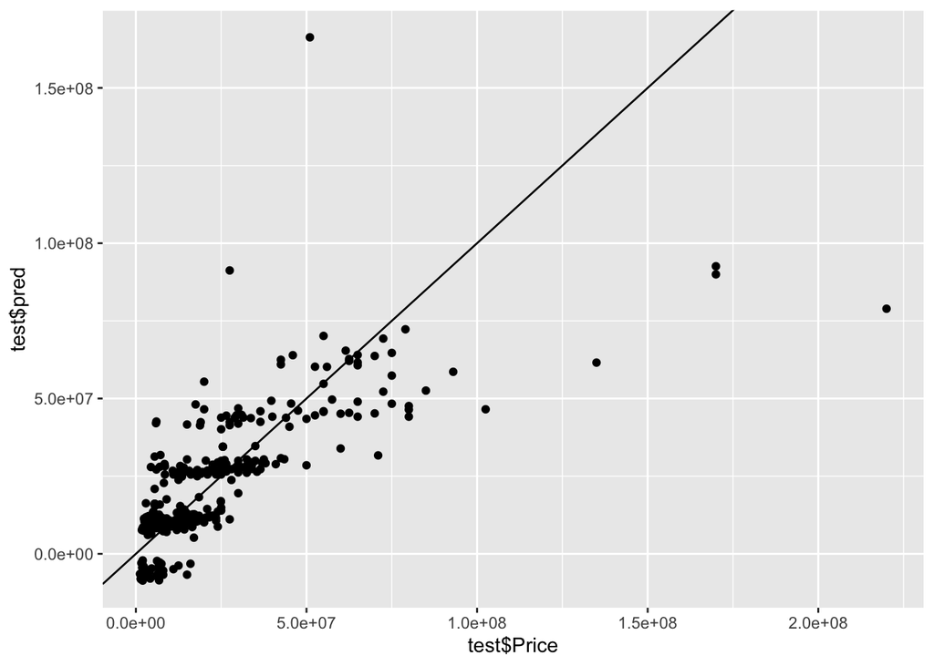

```r
test <- test %>% add_predictions(dat.lm3)
ggplot(test, aes(test$Price, test$pred)) +
  geom_point() +
  geom_abline()
```

Prediction $R^2$ for model 2 is:

```r
yhat_test = predict(dat.lm2, newdata = test)
rsq_test_rpart = 1 - mean((yhat_test - test$Price)^2)/var(test$Price)
rsq_test_rpart
```

```
## [1] 0.5648396
```

**So, 56.48 per cent of test variance is explained by regression model.**

## Tree-based Models

```r
rm(list = ls())

data = read.csv("DelhiHousingClean.csv", head = T, stringsAsFactors = T)
data = dplyr::select(data, -Per_Sqft, -Locality)


# Splitting data into training and test
set.seed(12345)
l = sample(nrow(data), size = 0.7*nrow(data))
train = data[l,]
test = data[-l,]
```

### Fitting CART via `rpart` Package

```r
library(rpart)
library(ipred)

# Training model using rpart library
fit0 = rpart(Price~., data = train, method="anova", control=rpart.control(minsplit=30,cp=0.001))
```

Multiple values of `minsplit` were tried and then 30 was chosen. Complexity parameter tells how much should the R squared increase by at least to consider an iteration. It is for pruning the needless branches.

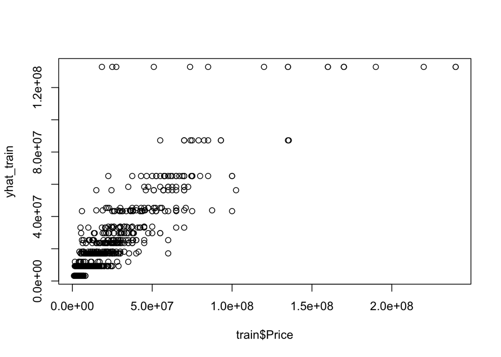

```r
# yhat_training
yhat_train = predict(fit0)
plot(train$Price, yhat_train)
```

```r
rsq_train_rpart = 1 - mean((yhat_train - train$Price)^2)/var(train$Price)
rsq_train_rpart
```

```
## [1] 0.7521806
```

Clearly there is heteroskedasticity problem as the error is blowing up as price increases and the training R squared is 75%.

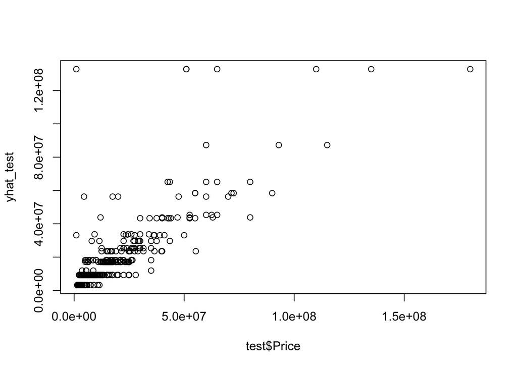

```r
# Let's see the testing R-squared
yhat_test = predict(fit0, newdata = test)
plot(test$Price, yhat_test)
```

```r
rsq_test_rpart = 1 - mean((yhat_test - test$Price)^2)/var(test$Price)
rsq_test_rpart
```

```
## [1] 0.5959859
```

**We get that 59.59 per cent of test variance is explained by CART model.**

### Bagging via `ipred` Package

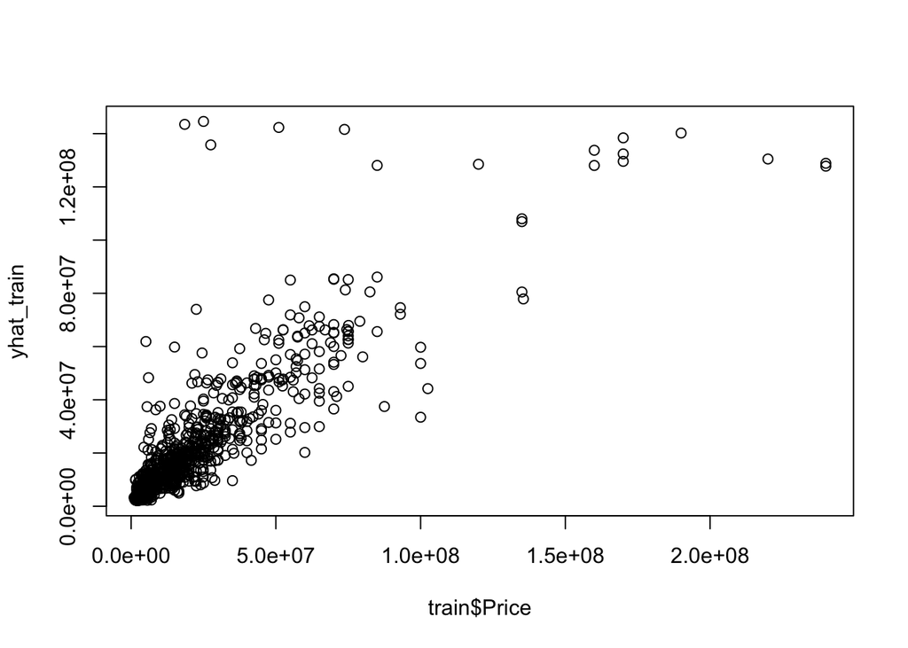

```r
library(ipred)
fit1 = bagging(Price~., data = train,nbagg=100,control=rpart.control(minsplit=30,cp=0))
# choosing 100 bootstrap replications. Higher will give better estimates but will make the machine very slow.

yhat_train = predict(fit1)
plot(train$Price, yhat_train)
```

```r
rsq_train_ipred = 1 - mean((yhat_train - train$Price)^2)/var(train$Price)
rsq_train_ipred
```

```
## [1] 0.7157328
```

So, our model is able to explain 71.57 per cent of training set variability.

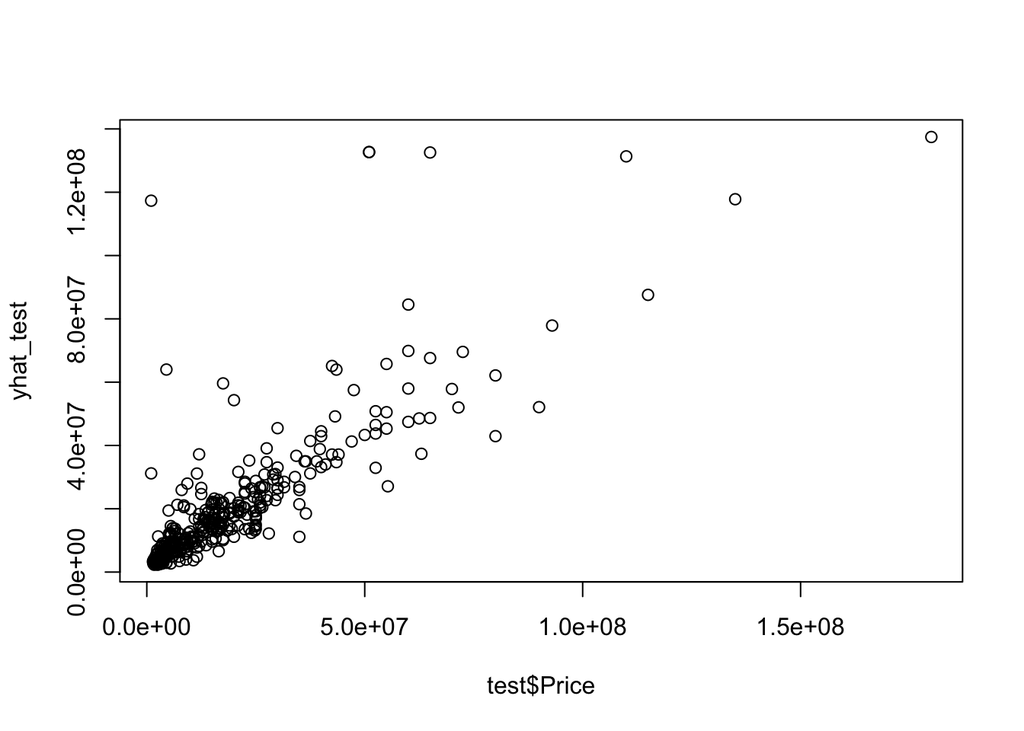

```r
# Testing ipred model
yhat_test = predict(fit1, newdata = test)
plot(test$Price, yhat_test)
```

```r
rsq_test_ipred = 1 - mean((yhat_test - test$Price)^2)/var(test$Price)
rsq_test_ipred
```

```
## [1] 0.6294822
```

**Using bagging approach via `ipred` library is able to predict 62.94 per cent of variability in test dataset.**

### Random Forest

```r
library(randomForest)
```

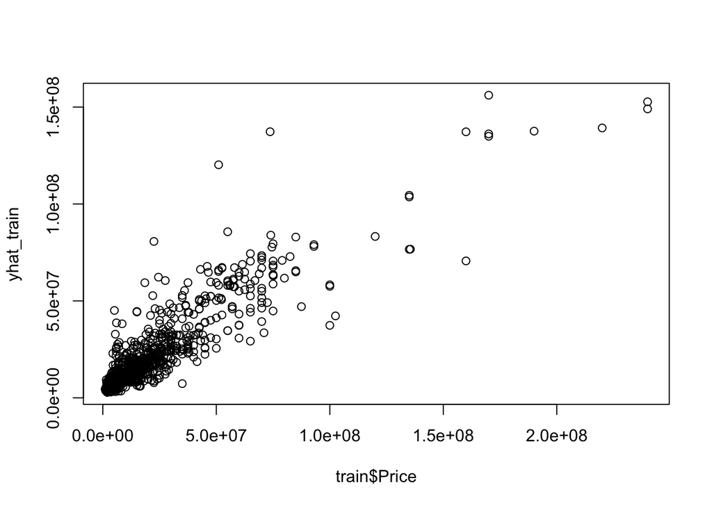

```r
fit_rf = randomForest(Price~.,data=train,ntree=500)

# training accuracy
yhat_train = predict(fit_rf)
plot(train$Price, yhat_train)
```

```r
rsq_train_randfor = 1 - mean((yhat_train - train$Price)^2)/var(train$Price)
rsq_train_randfor
```

```
## [1] 0.7963763
```

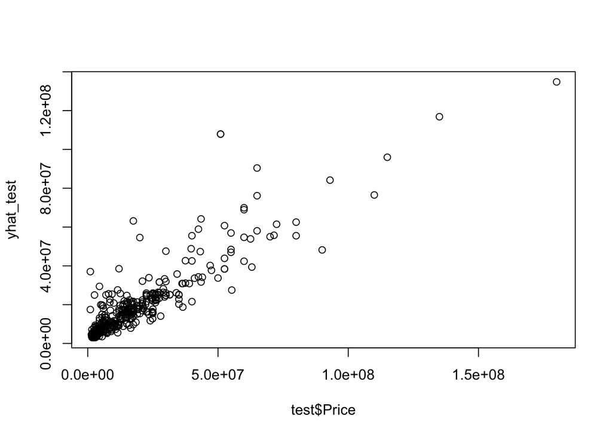

```r
# Testing ipred model
yhat_test = predict(fit_rf, newdata = test)
plot(test$Price, yhat_test)
```

```r
rsq_test_randfor = 1 - mean((yhat_test - test$Price)^2)/var(test$Price)
rsq_test_randfor
```

```
## [1] 0.7870888
```

**Random forest gives the prediction accuracy of 78.70 per cent, highest of all tree-based methods.**

## Splines

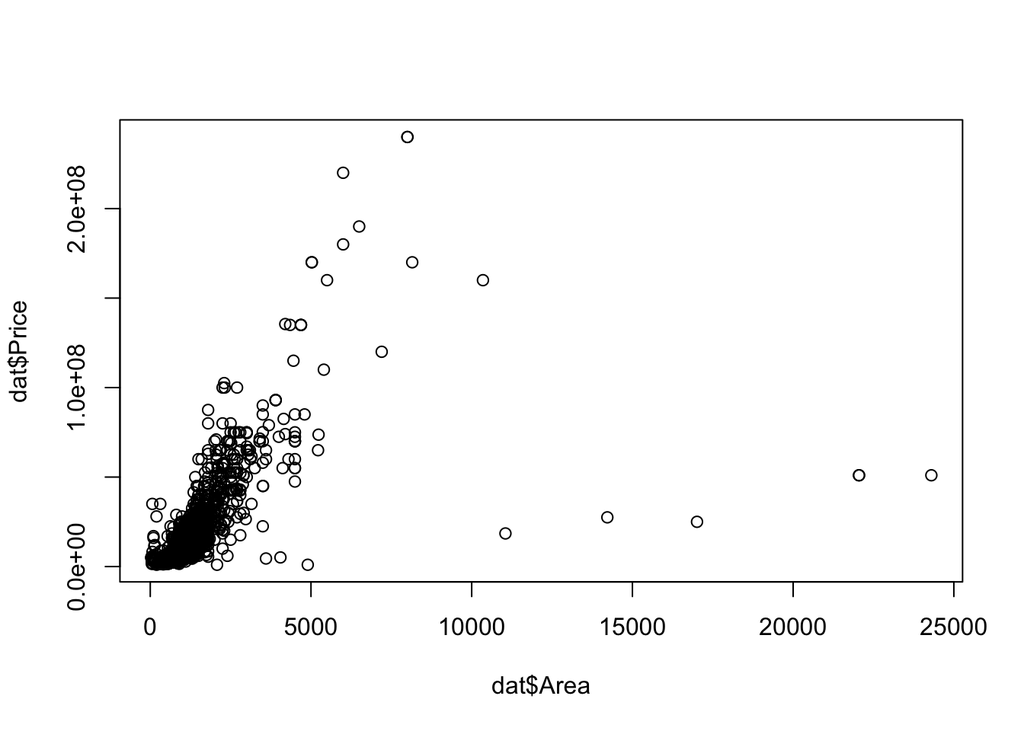

```r
rm(list = ls())
library(splines2)
library(tidyverse)
library(ggcorrplot)
library(splines)

dat = read.csv("DelhiHousingClean.csv", head = T, stringsAsFactors = T)

plot(dat$Price~dat$Area)
```

As splines only work with continuous variables, we will only use price and area for predictions. Few other variables can be called ordinal at best, but can’t be used properly with splines; while others are categorical in nature.

```r
y<-dat$Price[dat$Area<10000]
x<-dat$Area[dat$Area<10000]
```

### Choosing Knots Manually

```r
#Spline Regression (choosing knots manually)
splinemodel <- lm(y~bs(x, knots = c(2000,4000,6000,8000)), data = dat)
summary(splinemodel)
```

```
##
## Call:
## lm(formula = y ~ bs(x, knots = c(2000, 4000, 6000, 8000)), data = dat)
##
## Residuals:
##        Min         1Q     Median         3Q        Max
## -105813777   -4600765   -1128192    3684398   71578585
##
## Coefficients:
##                                            Estimate Std. Error t value Pr(>|t|)
## (Intercept)                                 9721013    1988666   4.888 1.15e-06
## bs(x, knots = c(2000, 4000, 6000, 8000))1 -18363106    3490204  -5.261 1.68e-07
## bs(x, knots = c(2000, 4000, 6000, 8000))2  41027605    2379188  17.244  < 2e-16
## bs(x, knots = c(2000, 4000, 6000, 8000))3  46382972    5375257   8.629  < 2e-16
## bs(x, knots = c(2000, 4000, 6000, 8000))4 156176312    8923652  17.501  < 2e-16
## bs(x, knots = c(2000, 4000, 6000, 8000))5 159591680   18397249   8.675  < 2e-16
## bs(x, knots = c(2000, 4000, 6000, 8000))6 233903052   10622715  22.019  < 2e-16
## bs(x, knots = c(2000, 4000, 6000, 8000))7 160278987   12212901  13.124  < 2e-16
##
## (Intercept)                               ***
## bs(x, knots = c(2000, 4000, 6000, 8000))1 ***
## bs(x, knots = c(2000, 4000, 6000, 8000))2 ***
## bs(x, knots = c(2000, 4000, 6000, 8000))3 ***
## bs(x, knots = c(2000, 4000, 6000, 8000))4 ***
## bs(x, knots = c(2000, 4000, 6000, 8000))5 ***
## bs(x, knots = c(2000, 4000, 6000, 8000))6 ***
## bs(x, knots = c(2000, 4000, 6000, 8000))7 ***
## ---
## Signif. codes:  0 '***' 0.001 '**' 0.01 '*' 0.05 '.' 0.1 ' ' 1
##
## Residual standard error: 12050000 on 1244 degrees of freedom
## Multiple R-squared:  0.7749, Adjusted R-squared:  0.7737
## F-statistic: 611.9 on 7 and 1244 DF,  p-value: < 2.2e-16
```

The adjusted $R^2$ is 77.37 per cent for training data set.

### Smooth Splines

```r
y.spline<-smooth.spline(x,y, df = 10)
summary(y.spline)
```

```
##            Length Class             Mode
## x          309    -none-            numeric
## y          309    -none-            numeric
## w          309    -none-            numeric
## yin        309    -none-            numeric
## tol          1    -none-            numeric
## data         3    -none-            list
## no.weights   1    -none-            logical
## lev        309    -none-            numeric
## cv.crit      1    -none-            numeric
## pen.crit     1    -none-            numeric
## crit         1    -none-            numeric
## df           1    -none-            numeric
## spar         1    -none-            numeric
## ratio        1    -none-            numeric
## lambda       1    -none-            numeric
## iparms       5    -none-            numeric
## auxM         0    -none-            NULL
## fit          5    smooth.spline.fit list
## call         4    -none-            call
```

```r
#str(y.spline)
length(y.spline$y)
```

```
## [1] 309
```

```r
y.fitted = predict(y.spline, x)
length(y.fitted$y)
```

```
## [1] 1252
```

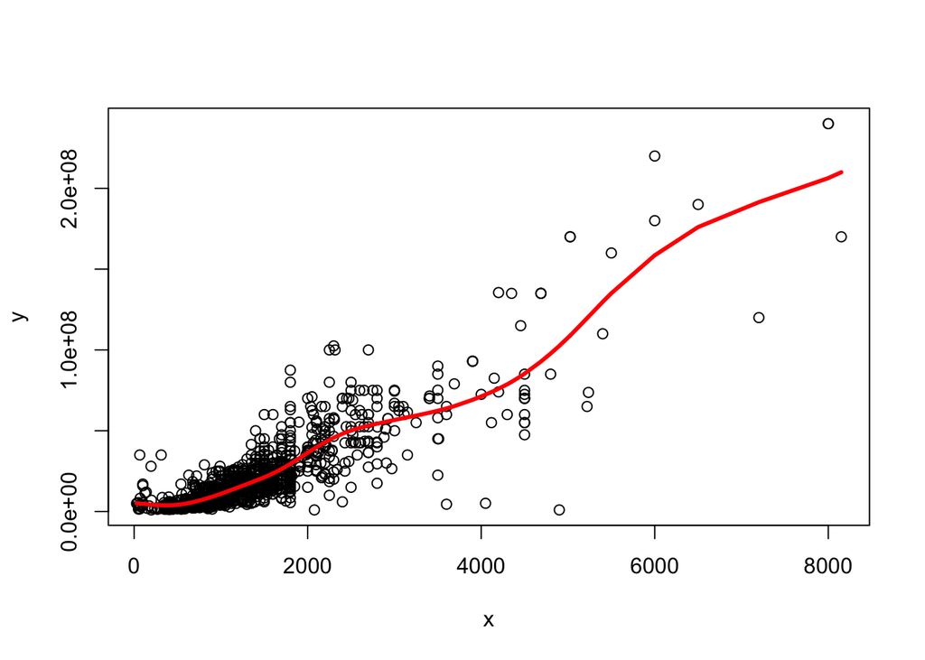

```r
plot(x,y); lines(y.spline, col = 'red', lwd = 3)
```

Let’s find SSE and $R^2$ for smooth splines.

```r
diff = y.fitted$y-y
diffsq = diff^2
SSE = sum(diffsq)
SST = sum((y-mean(y))^2)
SST
```

```
## [1] 8.025324e+17
```

```r
Rsqr.spline2 = 1-(SSE/SST)
Rsqr.spline2
```

```
## [1] 0.7770301
```

For smooth splines, the $R^2$ is 77.70 per cent.

## Artificial Neural Networks

```r
rm(list = ls())
data = read.csv("DelhiHousingClean.csv", head = T, stringsAsFactors = T)
data = dplyr::select(data, -Per_Sqft, -Locality)


#### Splitting data into training and test
set.seed(12345)
l = sample(nrow(data), size = 0.7*nrow(data))
train = data[l,]
test = data[-l,]

#### Fitting ANN models
# ---- ANN using nnet R package----------
library(nnet) # allows only one hidden layer

# Training model
Y = train$Price
n = length(Y)

train_price_scaled = (Y-min(Y))/(max(Y)-min(Y))
set.seed(12345)
fit2 = nnet(train_price_scaled ~ Area + BHK + Bathroom + Parking, data=train,size=3,
            trace=F,decay=0.001)
print(fit2$wts) # parameter estimates
```

```
##  [1] -0.0001124223 -0.5980313066 -0.0011381363 -0.0005108842 -0.0014810694
##  [6] -3.0531511151  0.0024728870  0.3410485542  0.1860633734 -0.0240722413
## [11]  2.4709929814 -0.0007080922  0.2817870632 -0.4215768618 -0.0173120302
## [16] -2.1203634403 -0.3152682736  2.2780353939 -3.0476127917
```

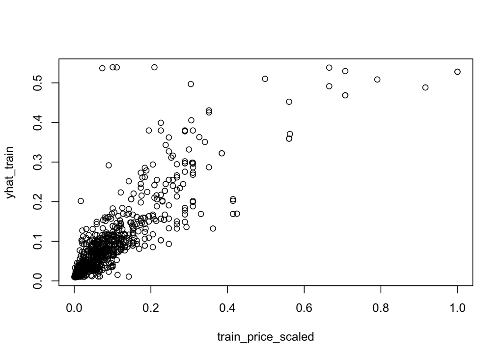

```r
# yhat_training
yhat_train = fit2$fitted.values
plot(train_price_scaled, yhat_train)
```

```r
rsq_train = 1 - mean((train_price_scaled - yhat_train)^2)/(var(train_price_scaled))
print(rsq_train)
```

```
## [1] 0.7070354
```

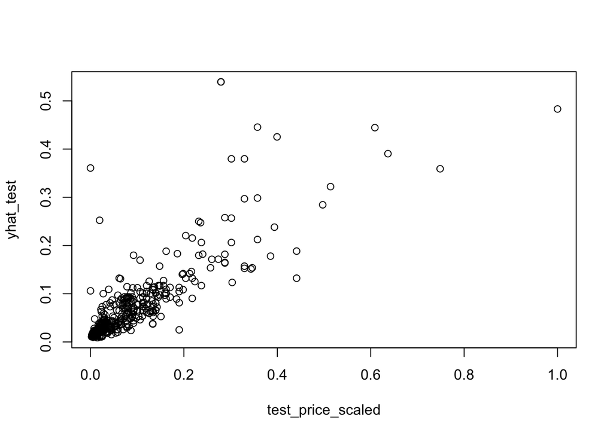

```r
# Testing model
Y = test$Price
n = length(Y)

test_price_scaled = (Y-min(Y))/(max(Y)-min(Y))
yhat_test = predict(fit2, newdata = test)
plot(test_price_scaled, yhat_test)
```

```r
rsq_test = 1 - sum((test_price_scaled - yhat_test)^2)/(var(test_price_scaled)*(n-1))
print(rsq_test)
```

```
## [1] 0.627136
```

But we see a possibly somewhat significant difference in $R^2$ train vs $R^2$ test. It might help to resample and try.

Apart from that, we can change “size” in our our model to get better R^2. By trial & error on sizes=1,2,3,4, we find that k=2 hidden nodes works best.

Now let’s try fitting using `neuralnet` R package which offers possibility of having >1 hidden layers.

```r
library(neuralnet)
```

```r
#--------1 hidden layer - 3 hidden variables--------#
## Training model
Y = train$Price
n = length(Y)
train_price_scaled = (Y-min(Y))/(max(Y)-min(Y))

fit2 = neuralnet(train_price_scaled ~ Area + BHK + Bathroom + Parking,
                 data=train, hidden=c(3,2), threshold = 0.01, linear.output=FALSE)
#--- network plot ----
plot(fit2)
```

[output not shown]

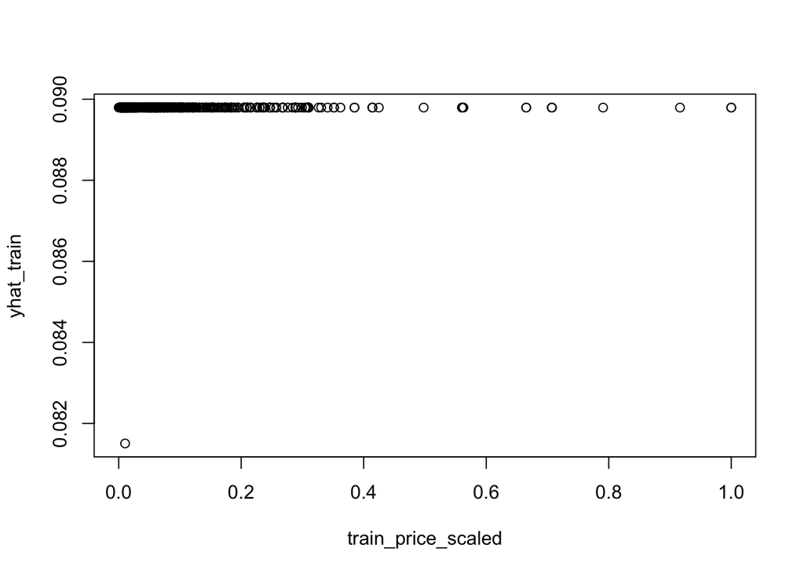

```r
# yhat_training

yhat_train = c((fit2$net.result)[[1]])
plot(train_price_scaled, yhat_train)
```

There seems to be an error in the package functioning as required. So, drop all operations based on this package and only consider the `nnet` package.

# Conclusion

Our aim was to best predict the house prices in New Delhi. We tried four different models: linear regression, tree-based methods, splines and artificial neural networks. The *goodness-of-fit* measures for each method with test data is listed below.

| Method | Test / Adjusted $R^2$ |
| --- | --- |
| Linear Regression | 56.48 % |
| CART via `rpart` Package | 59.59 % |
| Bagging via `ipred` Package | 62.94% |
| Random Forest | 78.70 % |
| Splines | 77.37 % |
| Smooth Splines | 77.70 % |
| Artificial Neural Network | 62.71 % |

Based on the accuracy, **random forest model is the best**. However, the limitation of this model is that it has very low interpretability. Linear regression model has lower accuracy in predictions, but has much better interpretability.

Our purpose in this project was to predict the house prices and Random Forest method does it best, with 78.70 % accuracy.

## Individual Contributions

- Aditya Badonia: Section on splines.
- Harshvardhan: Section on tree based models, visualisations and document compilation and formatting.
- Oshin Singal: Section on multilinear regression and data cleaning.
- P Suranjana: Section on artificial neural networks.